# Example Script

# Headline without Number

the number is not displayed due to the use of {-}

# 1 Headline 1

## 1.1 Headline 2

### 1.1.1 Headline 3

#### 1.1.1.1 Headline 4

##### 1.1.1.1.1 Headline 5

The different headers can also get names (see Headline 2 in the Markdown)  
These can be used to enter jumps to the respective headline

When writing text, you can create a new line  
by adding two spaces at the end.

Without two spaces everything will be in one line.

# 2 create unordered lists

- list 1 - item 1
- list 1 - item 2
  - list 1 - item 2.1
  - list 1 - item 2.2
    - list 1 - item 2.2.1

For each level you have to enter an additional tab

# 3 create ordered lists

1. list 2 - item 1
2. list 2 - item 2
   1. list 2 - item 2.1
   2. list 2 - item 2.2
      5. list 2 - item 2.2.1

Here, to have a second level you need to enter a tab and a space, for level 3 you need to enter two tabs and two spaces

# 4 enter text in different formats

## 4.1 italics

section needs to be frames by single ’ * ’ or ’ _ ’  
either *italics* or *italics*

## 4.2 bold

section needs to be frames by double ’ * ’ or ’ _ *  
either **bold** or **bold**

## 4.3 subscript

section needs be framed by ’ ~ ’  
e.g. H<sub>2</sub>O

## 4.4 superscript

section needs to be framed by ’ ^ ’  
e.g. H<sup>+</sup>

combined example: NH<sub>4</sub><sup>+</sup>

# 5 create Tables

| First column | Second column |
| --- | --- |
| First row | First row |
| Second row | Second row |

# 6 Enter Links

you can enter links by either adding the link in ’ < > ’ or setting the hyperlinkable word in square brackets and the link in round brackets (without space in between)  
examples: https://www.uni-koblenz-landau.de  
[Uni](https://www.uni-koblenz-landau.de)

# 7 enter in-line R code

to enter in-line R code you have to set these in `` and start with an r

example:

Instead of writing manually 2 + 2 = 4  
you could write 2 + 2 = 4

# 8 enter in-line Latex code

you can also enter in-line Latex code, when for example planning to enter special characters

examples:  
alpha: $\alpha$  
beta: $\beta$  
phi: $\phi$

using mouse over, you can have an immediate look if your Latex code is correct

like that you can also enter in-line equations

an example would be $y = x^2$

# 9 enter equations in seperate lines

you also also enter Latex based equations in separate lines  
to do that, you need to use two $. You will also get an immediate preview of your equation

$$k_{OW} = log \left( \frac{c_{1-octanol}}{c_{water}} \right)$$

# 10 Some other options

Enter dates:  
05.11.2020

Enter information about your dataframe:  
32  
11

# 11 Options for code chunks

To see what the different options are doing, we are using the example dataframe mtcars

You can (you don’t need to) give chunks a name, to correctly identify the respective code chunks  
Double chunk names, however, are prohibited.

## 11.1 hiding code

```
##
##  Pearson's product-moment correlation
##
## data:  mtcars$mpg and mtcars$drat
## t = 5.096, df = 30, p-value = 1.776e-05
## alternative hypothesis: true correlation is not equal to 0
## 95 percent confidence interval:
##  0.4360484 0.8322010
## sample estimates:
##       cor
## 0.6811719
```

```
##
##  Pearson's product-moment correlation
##
## data:  mtcars$am and mtcars$gear
## t = 7.1552, df = 30, p-value = 5.834e-08
## alternative hypothesis: true correlation is not equal to 0
## 95 percent confidence interval:
##  0.6158963 0.8949546
## sample estimates:
##       cor
## 0.7940588
```

## 11.2 hiding result

```r
cor.test(mtcars$cyl, mtcars$hp)
```

## 11.3 display all results at the end of a chunk

```r
cor.test(mtcars$drat, mtcars$carb)

cor.test(mtcars$vs, mtcars$wt)

cor.test(mtcars$qsec, mtcars$disp)
```

```
##
##  Pearson's product-moment correlation
##
## data:  mtcars$drat and mtcars$carb
## t = -0.49934, df = 30, p-value = 0.6212
## alternative hypothesis: true correlation is not equal to 0
## 95 percent confidence interval:
##  -0.4259976  0.2663358
## sample estimates:
##        cor
## -0.0907898
##
##
##  Pearson's product-moment correlation
##
## data:  mtcars$vs and mtcars$wt
## t = -3.6535, df = 30, p-value = 0.0009798
## alternative hypothesis: true correlation is not equal to 0
## 95 percent confidence interval:
##  -0.7571117 -0.2556982
## sample estimates:
##        cor
## -0.5549157
##
##
##  Pearson's product-moment correlation
##
## data:  mtcars$qsec and mtcars$disp
## t = -2.6363, df = 30, p-value = 0.01314
## alternative hypothesis: true correlation is not equal to 0
## 95 percent confidence interval:
##  -0.6796151 -0.1001493
## sample estimates:
##        cor
## -0.4336979
```

## 11.4 hiding messages

```r
library(dplyr)
```

now we detach the package

```r
detach("package:dplyr", unload=TRUE)
```

```r
library(dplyr)
```

now without message + warning

```r
detach("package:dplyr", unload=TRUE)
library(dplyr)
```

# 12 Add figures

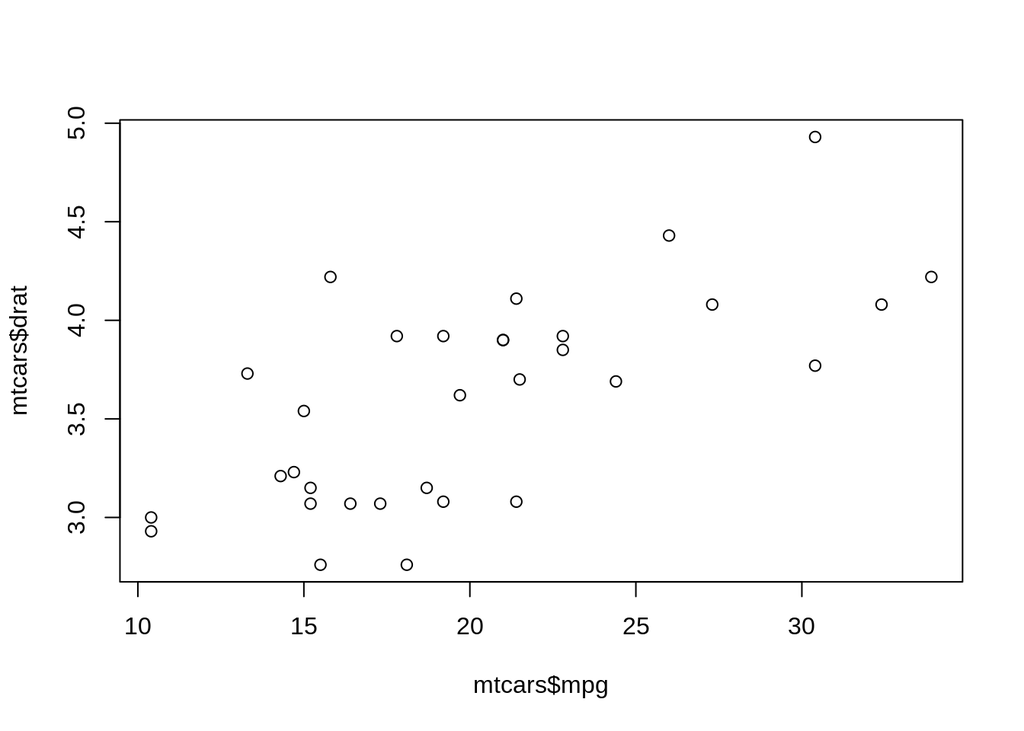

```r
plot(mtcars$mpg, mtcars$drat)
```